# Predicting movement effectiveness based on self quantification data

Levente Szabados

2015-10-23

# Executive summary

The goal of our present modeling attempt is to predict the effectiveness of persons movements based on the measurements collected by biometric sensors. After briefly exploring the data I build up a predictive model, analyse it’s effectiveness, and remark some caveats for further analysis.

# Data source and structure

For our experiments I use the human activity recognition data of **Pontifícia Universidade Católica do Rio de Janeiro**. The detailed description of the data can be found [here.](http://groupware.les.inf.puc-rio.br/har)

## The main characteristics of the dataset

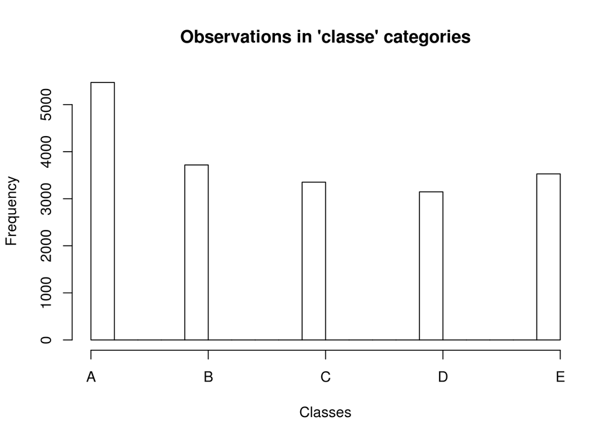

I want to predict the correctness of movements based on the variable **classe**, which is a factor variably, classifying movements into categories ranging from *A* to *E*.

The number of variables in the dataset is: $160$

I ommit the variables in columns 1 to 7 from the modeling, since they contain general timestamp and identification information. and subset the data accordingly.

Final number of datacolumns I use for training is: $52$

# Choice of prediction model and resampling

# Modeling

## Parameters

For our models to be reproducible, I set the random seed to:$121314$

Since the computational costs of training our models can easily become prohibitive, I had to override the default settings of the **CARET** package. (Even with using the **doMC** package, and registering **4 CPU cores** for computation, the running time was unmanageable. Thus I have experimented with changing the **ntrees** parameter for the training, decreasing it to **30** from the original default value, which provided acceptable computation time.

During training, I intend to use **repeated cross validation**. The parameter seems to exercise positive influence on accuracy, thus validation and repeat Ire set to **10**.

## First model

```r
cvCtrl <- trainControl(method = "repeatedcv", number = 10, repeats = 10, classProbs = TRUE)
mod_all<-train(classe~.,data=training,method="rf", ntree=30, trControl = cvCtrl)
mod_all
```

```
## Random Forest
##
## 19216 samples
##    52 predictors
##     5 classes: 'A', 'B', 'C', 'D', 'E'
##
## No pre-processing
## Resampling: Cross-Validated (10 fold, repeated 10 times)
## Summary of sample sizes: 17294, 17295, 17294, 17294, 17294, 17294, ...
## Resampling results across tuning parameters:
##
##   mtry  Accuracy   Kappa      Accuracy SD  Kappa SD
##    2    0.9929591  0.9910923  0.001957301  0.002476396
##   27    0.9940155  0.9924291  0.001936219  0.002449657
##   52    0.9893943  0.9865822  0.003116839  0.003943576
##
## Accuracy was used to select the optimal model using  the largest value.
## The final value used for the model was mtry = 27.
```

# Caveats about data

A more thorough analysis of the traininging data reveals, that there are **clusters of variables** within the traininging set, that have **significantly high correlation** with each-other.

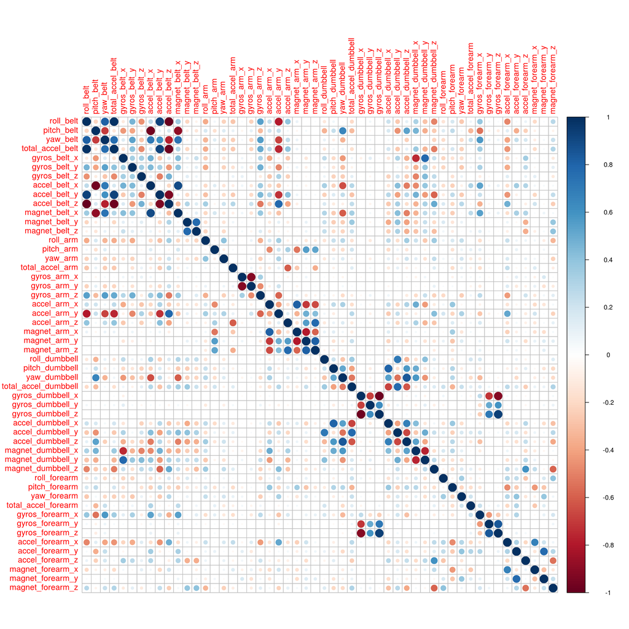

Here is a subset of the correlation matrix with a **threshold** of $0.7$ which can be considered high.

```
##                       row            column       cor
## 2               roll_belt          yaw_belt 0.8153069
## 4               roll_belt  total_accel_belt 0.9809160
## 6                yaw_belt  total_accel_belt 0.7621551
## 24               yaw_belt      accel_belt_x 0.7081443
## 29              roll_belt      accel_belt_y 0.9250067
## 32       total_accel_belt      accel_belt_y 0.9278914
## 48               yaw_belt     magnet_belt_x 0.7361600
## 53           accel_belt_x     magnet_belt_x 0.8915610
## 78          magnet_belt_y     magnet_belt_z 0.7799843
## 220          accel_belt_z       accel_arm_y 0.7869728
## 274           accel_arm_x      magnet_arm_x 0.8147930
## 323           accel_arm_z      magnet_arm_z 0.7781559
## 325          magnet_arm_y      magnet_arm_z 0.8144842
## 556        pitch_dumbbell  accel_dumbbell_x 0.8083464
## 588         roll_dumbbell  accel_dumbbell_y 0.7194434
## 591  total_accel_dumbbell  accel_dumbbell_y 0.7729116
## 624          yaw_dumbbell  accel_dumbbell_z 0.8489091
## 671          gyros_belt_x magnet_dumbbell_y 0.7803187
## 979      gyros_dumbbell_z   gyros_forearm_y 0.7194718
## 1023     gyros_dumbbell_z   gyros_forearm_z 0.9347067
## 1035      gyros_forearm_y   gyros_forearm_z 0.8478047
## 1273      accel_forearm_y  magnet_forearm_y 0.7723822
```

This result suggests, that since clusters of the variables are **not independent enough, their information value is questionable**, thus they can be **ommitted** from the prediction model, what would at least decrease complexity, or even decrease the possibility of overfitting.

```
##  [1] "roll_belt"            "yaw_belt"             "total_accel_belt"
##  [4] "accel_belt_x"         "magnet_belt_y"        "accel_belt_z"
##  [7] "accel_arm_x"          "accel_arm_z"          "magnet_arm_y"
## [10] "pitch_dumbbell"       "roll_dumbbell"        "total_accel_dumbbell"
## [13] "yaw_dumbbell"         "gyros_belt_x"         "gyros_dumbbell_z"
## [16] "gyros_forearm_y"      "accel_forearm_y"      "accel_belt_y"
## [19] "magnet_belt_x"        "magnet_belt_z"        "accel_arm_y"
## [22] "magnet_arm_x"         "magnet_arm_z"         "accel_dumbbell_x"
## [25] "accel_dumbbell_y"     "accel_dumbbell_z"     "magnet_dumbbell_y"
## [28] "gyros_forearm_z"      "magnet_forearm_y"
```

As a final experiment, I lookup the list above, where the total count of correlating variables is: $29$

If I consider all such variables, which themselves correlate with one other as not adding information, I can choose the ones that are members of correlation pairs **more than once** as more informative. I choose to ommit the less informative variables from the traininging set. [^1] The number of ommitted variables is: $20$

# Remodeling

```
## Random Forest
##
## 19216 samples
##    32 predictors
##     5 classes: 'A', 'B', 'C', 'D', 'E'
##
## No pre-processing
## Resampling: Cross-Validated (10 fold, repeated 10 times)
## Summary of sample sizes: 17294, 17295, 17294, 17296, 17295, 17293, ...
## Resampling results across tuning parameters:
##
##   mtry  Accuracy   Kappa      Accuracy SD  Kappa SD
##    2    0.9950405  0.9937259  0.001833612  0.002319799
##   17    0.9947804  0.9933972  0.001555912  0.001968223
##   32    0.9928705  0.9909813  0.001968750  0.002490280
##
## Accuracy was used to select the optimal model using  the largest value.
## The final value used for the model was mtry = 2.
```

After analysing the remodeling efforts, I can conclude, that the filtering of data variables **caused a minor increase in accuracy**, so this approach in this case seems favourable, thus our hypothesis about strong correlation betIen the variables seems warranted.

# Testing of the model

To **validate** our model obtained during the training session, I use the provided testing dataset available [here](https://d396qusza40orc.cloudfront.net/predmachlearn/pml-testing.csv). The number of datapoints in the testing dataset is: $20$

## Predictions for test cases:

$B, A, B, A, A, E, D, B, A, A, B, C, B, A, E, E, A, B, B, B$

After submission to the online system of *Coursera*, the calculation of validity **shows 100% accuracy.**

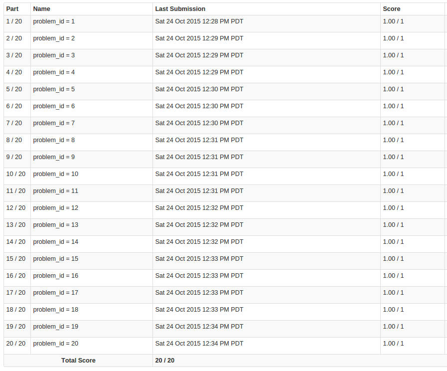

# Conclusions

**Based on above findings, I can conclude, that the quality of movements based on detailed measurements by self quantification tools can be predicted reliably.**

[^1]: The filtering of correlations under -0,7 could be also beneficial, but due to time constraints, I could not perform this analysis.